# High School Seniors t Test

```r
library(tidyverse)
library(DT)
library(pander)
library(readr)
library(ggplot2)
library(gridExtra)
library(car)

HSS <- read_csv("../../Data/HighSchoolSeniors.csv")
```

```r
HSSalt <- select(HSS, c(Reaction_time, Favourite_physical_activity))
HSSalt <- HSSalt %>%
  mutate(Athlete = ifelse(Favourite_physical_activity != "None", "Athlete", "Non-Athlete"))
HSSalt <- na.omit(filter(HSSalt, Reaction_time <= 2))
```

## Background

In the U.S. Census at School, 500 students from all over the country were surveyed about a wide range of topics, such as extra curricular participation, habits, measurements of foot length, and even desired super powers.

In the hundreds of students surveyed, there is a wide variety of abilities and skills shown. During high school, I recall a lot of pressure from teachers,parents, and peers to participate in sports. Reasons included higher physical and mental stimulation and growth, more appealing college applications, and increased social interactions. Using the favorite physical activity and the reaction time data collected during this survey, we can figure out if some of these allegations are true.

## Research Question

One supposed benefit of participation in sports is reaction time. Does participation in a sport or other physical activities result in better mental and physical development leading to higher reaction times? Taking the Favorite physical activity, we can group the students into two groups: those who participate in sports and those who do not. We can then compare the reaction times of the two groups to see if there is a notable difference. The null hypothesis is:
$$H_0: \mu_\text{Athletes} = \mu_\text{Non-Athletes}$$
with the alternative hypothesis being:
$$H_0: \mu_\text{Athletes} \neq \mu_\text{Non-Athletes}$$

## Analysis

For this analysis, all values with reaction time greater than 2 have been removed. It should be noted that there are many more athletes than non-athletes in the survey. The distribution for both is right skewed as well. However, the sample size for non athletes is still sufficient to assume normal distribution of means.

### T-Test Requirements

As shown in the histograms below, both data sets are right skewed, even when the extreme outliers are removed. The qq plots in the appendix show that the Athlete sample is extremely right-skewed. However both the non-athletes and the athletes sample sizes are large enough to assume normal distribution of the difference of the sample means, satisfying the requirements for an independent samples T-test.

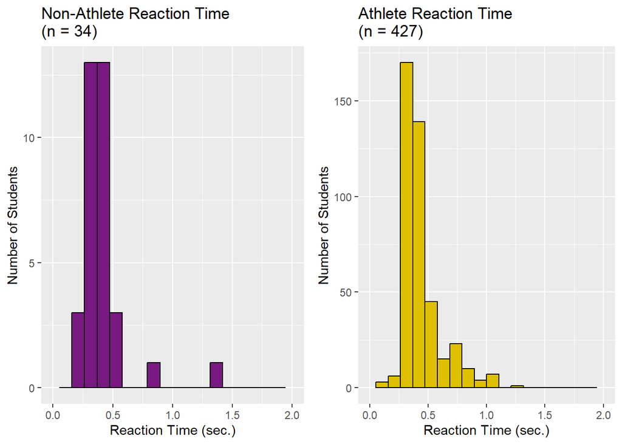

```r
#Create separate data for both groups and display them together in histograms
plot1 <- filter(HSSalt, Athlete == "Non-Athlete")
plot2 <- filter(HSSalt, Athlete == "Athlete")

hist1 <- ggplot(plot1, aes(x = Reaction_time)) +
  geom_histogram(bins = 20,
                 fill = "#781981",
                 color = "black") +
  xlim(0, 2) +
  labs(title = "Non-Athlete Reaction Time\n(n = 34)",
       x = "Reaction Time (sec.)",
       y = "Number of Students")

hist2 <- ggplot(plot2, aes(x = Reaction_time)) +
  geom_histogram(bins = 20,
                 fill = "#DFC000",
                 color = "black") +
  xlim(0, 2) +
  labs(title = "Athlete Reaction Time\n(n = 427)",
       x = "Reaction Time (sec.)",
       y = "Number of Students")

# Uses gridExtra library to position plots side by side
grid.arrange(hist1, hist2, ncol = 2)
```

### Summary Graphics

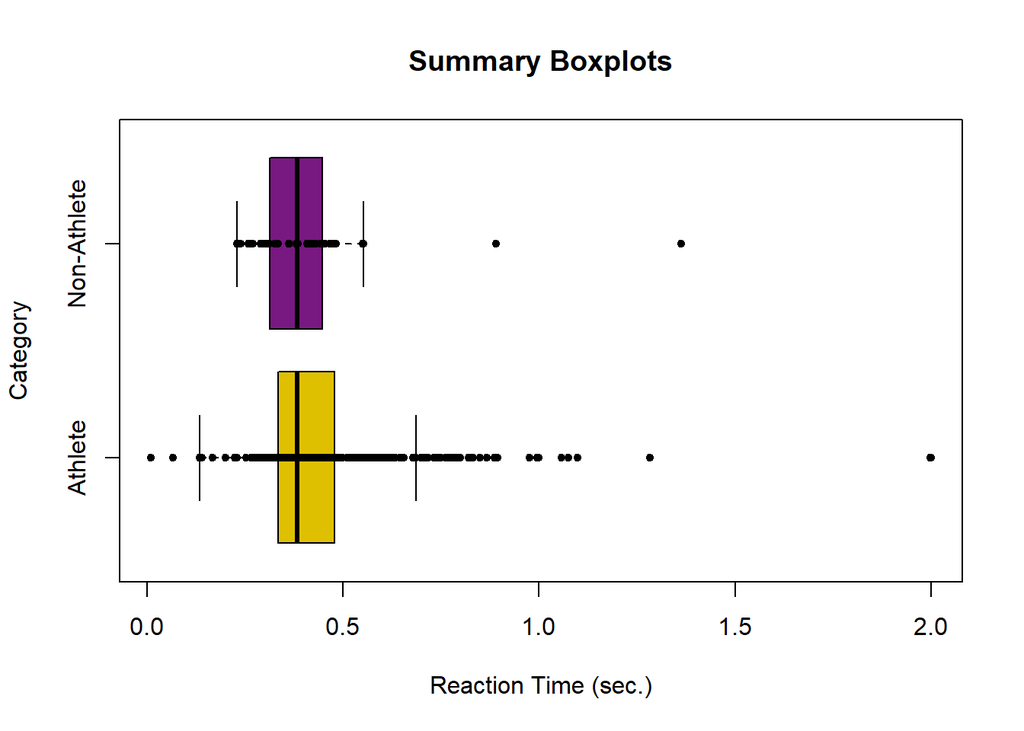

```r
boxplot(Reaction_time~Athlete,
        data = HSSalt,
        pch = 20,
        col = c("#DFC000", "#781981"),
        main = "Summary Boxplots",
        xlab = "Reaction Time (sec.)",
        ylab = "Category",
        horizontal = TRUE)

stripchart(Reaction_time ~ Athlete,
                  data = HSSalt,
                  add = TRUE,
                  pch = 20)
```

```r
# Table
table = HSSalt %>%
  group_by(Athlete) %>%
  summarise(Count = n(),
            Mean = round(mean(Reaction_time), 2),
            Min. = round(min(Reaction_time), 2),
            Q1 = round(quantile(Reaction_time, .25), 2),
            Median = round(median(Reaction_time), 2),
            Q3 = round(quantile(Reaction_time, .75), 2),
            Max. = round(max(Reaction_time), 2))

pander(table)
```

| Athlete | Count | Mean | Min. | Q1 | Median | Q3 | Max. |
| --- | --- | --- | --- | --- | --- | --- | --- |
| Athlete | 427 | 0.45 | 0.01 | 0.34 | 0.38 | 0.48 | 2 |
| Non-Athlete | 34 | 0.42 | 0.23 | 0.32 | 0.38 | 0.45 | 1.36 |

### T-Test Conclusions

```r
t.test(Reaction_time ~ Athlete,
       data = HSSalt,
       mu = 0,
       alternative = "two.sided",
       conf.level= .95)
```

```
##
##  Welch Two Sample t-test
##
## data:  Reaction_time by Athlete
## t = 0.76887, df = 38.988, p-value = 0.4466
## alternative hypothesis: true difference in means between group Athlete and group Non-Athlete is not equal to 0
## 95 percent confidence interval:
##  -0.04624968  0.10297141
## sample estimates:
##     mean in group Athlete mean in group Non-Athlete
##                 0.4465667                 0.4182059
```

According to the above T-test, the resulting p-value indicates that there is not enough evidence to reject the null hypothesis. In other words, there is not enough evidence to suggest that people who participate in sports have higher reaction times. According to this data, the mean reaction time for athletes is actually slower. One potential problem with this analysis could be the sample size for the non-athletes. Future analysis should be done to determine if athletic participation provides any other benefits, such as better memory or less pressure from schoolwork.

## Appendix

### QQ Plots

The qq plots below show that there are lots of outliers in both groups. The athlete group is especially right skewed. As discussed in the analysis above, this does not invalidate the t test because of the sample sizes.

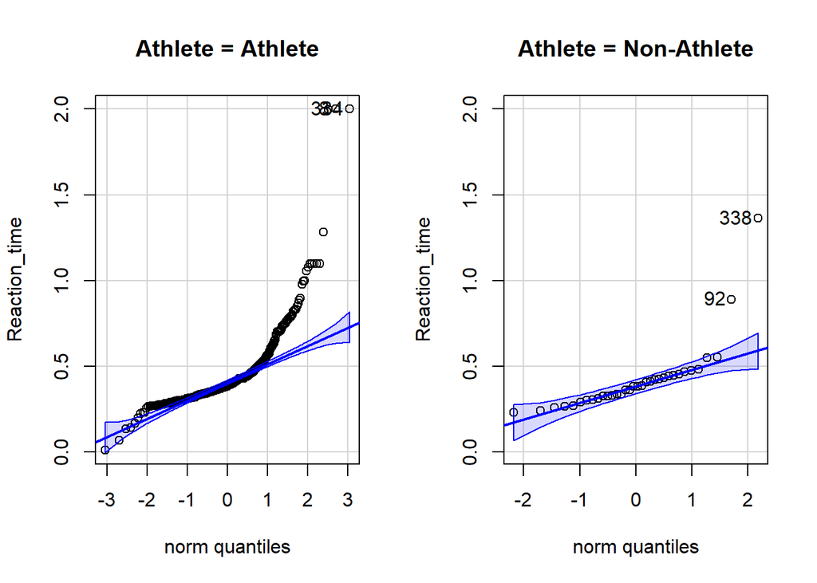

```r
qqPlot(Reaction_time~Athlete, data = HSSalt)
```

### Data (culled)

```r
datatable(HSSalt, extensions="Responsive", options=list(lengthMenu=c(5,10,30)))
```

|  | Reaction_time | Favourite_physical_activity | Athlete |
| --- | --- | --- | --- |
| 1 | 0.349 | Baseball/Softball | Athlete |
| 2 | 0.358 | Swimming | Athlete |
| 3 | 0.447 | Lacrosse | Athlete |
| 4 | 0.29 | None | Non-Athlete |
| 5 | 0.438 | Swimming | Athlete |
| 6 | 0.542 | Lacrosse | Athlete |
| 7 | 0.23 | None | Non-Athlete |
| 8 | 2 | Football (American) | Athlete |
| 9 | 0.428 | Swimming | Athlete |
| 10 | 0.337 | Basketball | Athlete |

[output cut: 451 more lines]